# hw3

## Analiza danych: Medical Expenditure Panel Survey

Cel: predykcja wydatków związanych z leczeniem

```python
import pandas as pd
from sklearn.model_selection import train_test_split
from sklearn.metrics import r2_score
from sklearn.ensemble import GradientBoostingRegressor
from sklearn.model_selection import train_test_split
import matplotlib.pyplot as plt
import numpy as np
import lime.lime_tabular
from IPython.display import Image
import matplotlib.pyplot as plt
from sklearn.linear_model import Ridge
import pandas as pd
from sklearn.metrics import classification_report
```

```python
def train_predict(model, X_train, X_test, y_train, y_test):
    model.fit(X_train, y_train)
    y_pred_train = model.predict(X_train)
    y_pred_test = model.predict(X_test)
    print('Training R^2:', r2_score(y_train, model.predict(X_train)))
    print('Test R^2:', r2_score(y_test, model.predict(X_test)))

    plt.plot([0, 100000], [0, 100000], lw=2, color='orange')
    plt.scatter(y_train, y_pred_train)
    plt.xlabel("y_train")
    plt.ylabel("y_train_pred")
    plt.show()
    plt.plot([0, 100000], [0, 100000], lw=2, color='orange')
    plt.scatter(y_test, y_pred_test)
    plt.xlabel("y_test")
    plt.ylabel("y_test_pred")
    plt.show()
    return model, y_pred_test
```

Domyślne przetwarzanie danych (funkcja default_preprocessing wywoływana jest podczas wczytywania danych MEPSDataset z pakietu aix360).

```python
def default_preprocessing(df):
    df = df[df['RACEV2X'].isin(['1','2'])]
    df = df[df['HISPANX'] == 2]

    racedict = {1.0: 0.0,2.0: 1.0}
    df = df.assign(RACEV2X = df['RACEV2X'].replace(to_replace = racedict))
    df = df.rename(columns = {'RACEV2X' : 'RACE3'})

    genderdict = {1.0: 0.0,2.0: 1.0}
    df = df.assign(SEX = df['SEX'].replace(to_replace = genderdict))
    df = df.rename(columns = {'SEX' : 'GENDER'})
    df = df.rename(columns = {'PERWT15F' : 'PERSONWT'})
    df = df.rename(columns = {'REGION31' : 'REGION'})
    df = df.rename(columns = {'TTLP15X' : 'INCOME_M'})
    df = df.rename(columns = {'TOTEXP15' : 'HEALTHEXP'})

    df = df[df['REGION'] >= 0] # remove values -1
    df = df[df['AGE31X'] >= 0] # remove values -1

    df = df[df['MARRY31X'] >= 0] # remove values -1, -7, -8, -9
    df = df[df['INCOME_M'] >= 0]

    df = df[(df[['EDRECODE','FTSTU31X','ACTDTY31','HONRDC31','RTHLTH31','MNHLTH31','HIBPDX','CHDDX','ANGIDX',
                 'MIDX','OHRTDX','STRKDX','EMPHDX','CHBRON31','CHOLDX','CANCERDX','DIABDX',
                 'JTPAIN31','ARTHDX','ARTHTYPE','ASTHDX','ADHDADDX','PREGNT31','WLKLIM31',
                 'ACTLIM31','SOCLIM31','COGLIM31','DFHEAR42','DFSEE42','ADSMOK42',
                 'PHQ242','EMPST31','POVCAT15','INSCOV15']] >= -1).all(1)]  #for all other categorical features, remove values < -1
    df = df[['BRSTEX53','DOBMM','HIBPAGED','MDDLRS42','CHDAGED','BMINDX53','CLNTRE53','REGION','AGE31X','GENDER','RACE3','MARRY31X',     # dropped 'EDUCYR', 'HIDEG' as data distributions are weird across panels,
             'EDRECODE','FTSTU31X','ACTDTY31','HONRDC31','RTHLTH31','MNHLTH31','HIBPDX','CHDDX','ANGIDX',
             'MIDX','OHRTDX','STRKDX','EMPHDX','CHBRON31','CHOLDX','CANCERDX','DIABDX',
             'JTPAIN31','ARTHDX','ARTHTYPE','ASTHDX','ADHDADDX','PREGNT31','WLKLIM31',
             'ACTLIM31','SOCLIM31','COGLIM31','DFHEAR42','DFSEE42','ADSMOK42','PCS42',
             'MCS42','K6SUM42','PHQ242','EMPST31','POVCAT15','INSCOV15','INCOME_M','HEALTHEXP','PERSONWT']]

    df['HEALTHEXP'].mean(), df['INCOME_M'].mean()
    return df
```

```python
data = pd.read_csv("h181.csv")
data.drop(columns = ['PANEL'], inplace=True)
data = default_preprocessing(data)
```

#### Wartości zmiennej objaśnianej

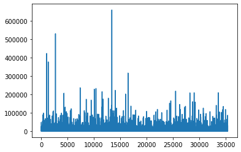

```python
plt.plot(data.HEALTHEXP)
```

```python
data = data[data['HEALTHEXP']<125000]
data = data.dropna(axis='columns')
```

#### Wartości zmiennej objaśnianej po usunięciu obserwacji z wydatkami na leczenie wyższymi niż 125 000

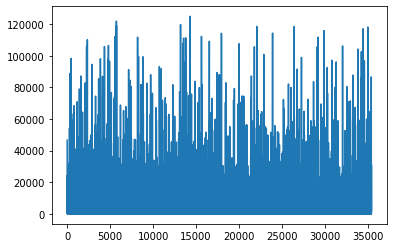

```python
plt.plot(data.HEALTHEXP)
```

#### Lista zmiennych z wartościami kategorycznymi

Zmiana typu zmiennych kategorycznych na *category*

```python
colCateg = ['REGION','MARRY31X','EDRECODE','FTSTU31X','ACTDTY31','HONRDC31',
            'RTHLTH31','MNHLTH31','HIBPDX','CHDDX','ANGIDX','MIDX','OHRTDX','STRKDX',
            'EMPHDX','CHBRON31','CHOLDX','CANCERDX','DIABDX','JTPAIN31','ARTHDX',
            'ARTHTYPE','ASTHDX','ADHDADDX','PREGNT31','WLKLIM31','ACTLIM31','SOCLIM31',
            'COGLIM31','DFHEAR42','DFSEE42','ADSMOK42','PHQ242','EMPST31','POVCAT15','INSCOV15']
```

```python
for cat in colCateg:
    data[cat] = data[cat].astype('category')
```

Podział zbioru na część treningową i testową odpowiednio w proporcjach 0.9:0.1.  
Wytrenowany model to **GradientBoostingRegressor**.  
Poniższe wykresy przedstawiają porównanie wartości predykcji modelu z prawdziwymi wartościami wydatów na leczenie.

```
Training R^2: 0.5158630319614359
Test R^2: 0.23400189691935547
```

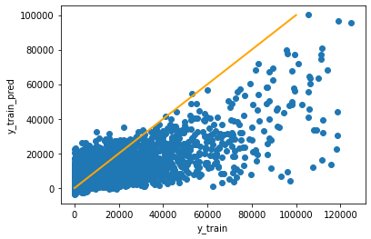

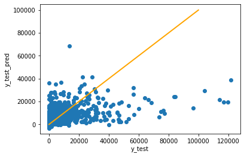

```python
X_train1, X_test1, y_train1, y_test1 = train_test_split(data.drop({"HEALTHEXP"},1), data['HEALTHEXP'], test_size=0.1, random_state=22)
raw_model = GradientBoostingRegressor(n_estimators=500, random_state=0)
raw_model, y_pred_test = train_predict(raw_model, X_train1, X_test1, y_train1, y_test1)
```

### 2) Predykcja na wybranych obserwacjach:

1) Obserwacja o najlepiej oszacowanych wydatkach na leczenie  
2) Obserwacja o najbardziej zawyżonych wydatkach na leczenie  
3) Obserwacja o najbardziej zaniżonych wydatkach na leczenie

```python
predictions = pd.DataFrame([y_test1.to_list(), y_pred_test]).T.rename({0:"y_test", 1:"y_pred"},axis=1)
predictions['diff']=predictions['y_test']-predictions['y_pred']
predictions['abs_diff'] = np.abs(predictions['diff'])
obs1 = predictions.abs_diff.idxmin()
obs2 = predictions['diff'].idxmin()
obs3 = predictions['diff'].idxmax()
obs = predictions.iloc[[obs1, obs2, obs3]]
```

Na pomarańczowo zaznaczone są wybrane obserwacje wraz z prawdziwymi wartościami i predykcją wydatków.

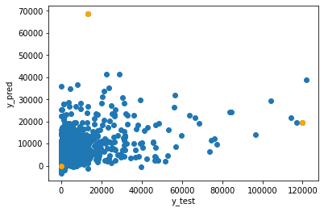

```python
plt.plot([0, 10], [0, 10], lw=2, color='orange')
plt.scatter(predictions['y_test'], predictions['y_pred'])
plt.scatter(obs['y_test'], obs['y_pred'], color='orange')
plt.xlabel("y_test")
plt.ylabel("y_pred")
plt.show()
```

### 3 i 4) LIME

```python
categorical_features = np.argwhere(np.array([len(set(X_train1.values[:,x])) for x in range(X_train1.values.shape[1])]) <= 10).flatten()
```

```python
explainer = lime.lime_tabular.LimeTabularExplainer(X_train1.values,
                                                    feature_names=X_train1.columns.values.tolist(),
                                                    class_names=['price'],
                                                    categorical_features=categorical_features,
                                                    verbose=True, mode='regression')
```

Wyjaśnienie dla obserwacji o najbliższej predykcji:  
*negatywnie* na predykcję wpłynęły wartości:

- *nie dotyczy* zmiennej **CHDAGED** (wartość wieku rozpoznania choroby niedokrwiennej serca)
- ograniczenie w funkcjonowaniu (fizycznym) **WLKLIM31**
- brak ograniczeń społecznych **SOCLIM31**

*pozytywnie* wpłynęła:

- wysoka wartość indeksu **K6SUM42** (im wyższa wartość indeksu, tym większa skłonność osoby do niepełnosprawności umysłowej)

```python
exp1 = explainer.explain_instance(X_test1.values[obs1], raw_model.predict, num_features=10)
#exp1.show_in_notebook(show_table=True)
```

```
Intercept 35035.568066648644
Prediction_local [8197.72011187]
Right: 1.1231701346182374
```

[figure not shown]

Wyjaśnienie dla obserwacji o najbardziej zawyżonych wydatkach na leczenie:  
*negatywnie* na predykcję wpłynęły wartości:

- brak ograniczeń społecznych **SOCLIM31**
- brak opóźnienia w opiece medycznej **MIDDLERS42** (zmienna wskazująca na powody opóźnienia leczenia)

*pozytywnie* wpłynęła:

- Rozpoznanie choroby niedokrwiennej serca **CHDAGED** (zmienna określająca wiek rozpoznania)
- wysoka wartość indeksu **K6SUM42** (im wyższa wartość indeksu, tym większa skłonność osoby do niepełnosprawności umysłowej)

```python
exp2 = explainer.explain_instance(X_test1.values[obs2], raw_model.predict, num_features=10)
#exp2.show_in_notebook(show_table=True)
```

```
Intercept 17355.957502841644
Prediction_local [30426.132978]
Right: 68763.32711376506
```

[figure not shown]

Porównując oba wyjaśnienia, model wydaje się dość stabilny. Podobne zmienne okazały się najważniejsze dla obu obserwacji. Wysokie wartości **CHDAGED** istotnie wpłynęły pozytywnie na wysokość wydatków, zaś niskie wpłynęły negatywnie.

### 5) Drugi model: regresja grzbietowa

```python
clf = Ridge(alpha=1.0)
clf.fit(X_train1, y_train1)
print('Training R^2:', r2_score(y_train1, clf.predict(X_train1)))
print('Test R^2:', r2_score(y_test1, clf.predict(X_test1)))
```

```
Training R^2: 0.2209697558069168
Test R^2: 0.1808751807381408
```

```python
data.iloc[obs1].HEALTHEXP
```

```
2877
```

```python
clf.predict(pd.DataFrame(data.iloc[obs1]).T.drop("HEALTHEXP",1))
```

```
array([906.0912927])
```

```python
exp1 = explainer.explain_instance(X_test1.values[obs1], clf.predict, num_features=10)
#exp1.show_in_notebook(show_table=True)
```

```
Intercept 13826.891146791997
Prediction_local [970.11602184]
Right: -482.4925418818166
```

[figure not shown]